# CDA and EDA

Kevin Thompson and Stuart Miller

Last Updated June 29, 2019

# Setup

### Load Libraries

```r
# load libraries used in this analysis
library(tidyverse)
library(naniar)
library(maps)
library(mapproj)
```

### Load Data

Be sure to run `make` in `./analysis/data` first to build data file.

```r
# load data from `make` operation listed above
load('./data/.RData')
```

## Introduction

This is an analysis of a dataset containing beer and brewery data. The dataset contains 2410 beers from 558 breweries in 50 states of the United States and the District of Columbia. The goal was to explore the data set and look for interesting features of the data. Once the data was explored, the analysis focused on how international bitterness unit (IBU) and alcohol by volume (ABV) of beer are distributed over states and the relationship between IBU and ABV. The analysis also includes a discussion of the missing data and how the missing data impacts making insights from the dataset.

## Analysis Questions

The following questions were used to drive the data exploration.

**How many breweries are present in each state?**

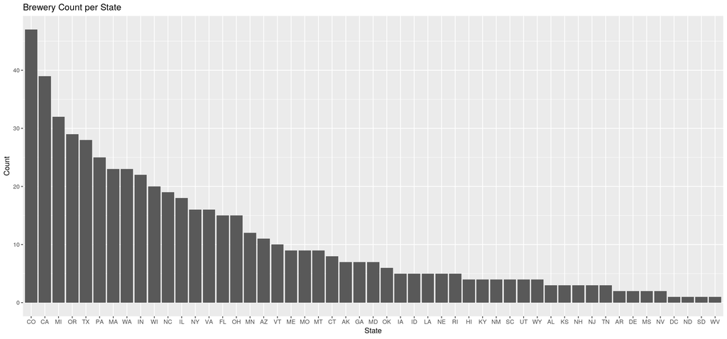

```r
# get counts of breweries per state
brewery_data %>%
  group_by(State) %>%
  summarise(breweries_per_state = length(State)) %>%
  ggplot(aes(x=reorder(State, -breweries_per_state), y=breweries_per_state)) +
  geom_col() +
  xlab('State') +
  ylab('Count') +
  ggtitle('Brewery Count per State')
```

Above is a plot of the number of breweries per state for each state and Washington DC.

About one-third of the states have more than 10 breweries, while the other two-thirds have less than 10. There are 47 breweries in Colorado and 39 in Califoria, which are the top two states by brewery count. The bottom three states by brewery count with just one brewery per state are North Dakota, South Dakota, and West Virginia. There is also only one brewery in Washington DC.

We next examine the data to ensure that data files were merged correctly.

```r
# print head and tail of data frame to show merge
# worked correctly
head(merged_data)
```

```
##   State Brewery_id                 Brewery_name      City
## 1    AK        494 Broken Tooth Brewing Company Anchorage
## 2    AK        459  Kenai River Brewing Company  Soldotna
## 3    AK        454       Denali Brewing Company Talkeetna
## 4    AK        271      Alaskan Brewing Company    Juneau
## 5    AK        494 Broken Tooth Brewing Company Anchorage
## 6    AK        459  Kenai River Brewing Company  Soldotna
##                         Beer_name Beer_ID   ABV IBU
## 1                  Polar Pale Ale     920 0.052  17
## 2 Peninsula Brewers Reserve (PBR)    1187 0.050  15
## 3               Single Engine Red     929 0.058  46
## 4                   Alaskan Amber    1920 0.053  18
## 5             Chugach Session Ale     919 0.048  NA
## 6               Sunken Island IPA     349 0.068  NA
##                     Style Ounces ShortStyle region
## 1 American Pale Ale (APA)     12        Ale alaska
## 2     American Blonde Ale     12        Ale alaska
## 3           Irish Red Ale     12        Ale alaska
## 4                 Altbier     12    Altbier alaska
## 5               Cream Ale     12        Ale alaska
## 6            American IPA     12        IPA alaska
```

```r
tail(merged_data)
```

```
##      State Brewery_id                    Brewery_name     City
## 2405    WY        458 The Black Tooth Brewing Company Sheridan
## 2406    WY        192     Snake River Brewing Company  Jackson
## 2407    WY        192     Snake River Brewing Company  Jackson
## 2408    WY        551      Wind River Brewing Company Pinedale
## 2409    WY         80     Black Tooth Brewing Company Sheridan
## 2410    WY        458 The Black Tooth Brewing Company Sheridan
##                             Beer_name Beer_ID   ABV IBU
## 2405    Saddle Bronc Brown Ale (2013)    1198 0.048  16
## 2406               Snow King Pale Ale    1606 0.060  55
## 2407                Snake River Lager     406 0.050  18
## 2408                 Wyoming Pale Ale     324 0.072  NA
## 2409        Bomber Mountain Amber Ale    2484 0.046  20
## 2410 Bomber Mountain Amber Ale (2013)    1200 0.046  20
##                         Style Ounces ShortStyle  region
## 2405        English Brown Ale     12        Ale wyoming
## 2406  American Pale Ale (APA)     12        Ale wyoming
## 2407             Vienna Lager     12      Lager wyoming
## 2408  American Pale Ale (APA)     16        Ale wyoming
## 2409 American Amber / Red Ale     12        Ale wyoming
## 2410 American Amber / Red Ale     12        Ale wyoming
```

Based on the first 6 and last 6 rows of the merged data, the merge appears to have been executed correctly. Note that this would only catch gross errors from the merge.

**Behavior of Missing Data**

```
## # A tibble: 12 x 4
##    variable     n_miss pct_miss n_miss_cumsum
##    <chr>         <int>    <dbl>         <int>
##  1 IBU            1005   41.7            1067
##  2 ABV              62    2.57             62
##  3 Style             5    0.207          1072
##  4 ShortStyle        5    0.207          1077
##  5 State             0    0                 0
##  6 Brewery_id        0    0                 0
##  7 Brewery_name      0    0                 0
##  8 City              0    0                 0
##  9 Beer_name         0    0                 0
## 10 Beer_ID           0    0                 0
## 11 Ounces            0    0              1072
## 12 region            0    0              1077
```

The table below, shows the number of missing values (`NA`) for `IBU`, `ABV`, `Style`, and `ShortStyle`. A large portion of the `IBU` values are missing, which would affect insightes related to `IBU`. The number of missing values for `ABV` is less significant, but caution should be taken when working with this column. The other two columns are missing less than 1% of the rows. Note: `ShortStyle` was computed from `Style`.

| Column Name | Number of Missing Values | Percent of Values Missing |
| --- | --- | --- |
| IBU | 1005 | 41.70% |
| ABV | 62 | 2.57% |
| Style | 5 | 0.21% |
| ShortStyle | 5 | 0.21% |

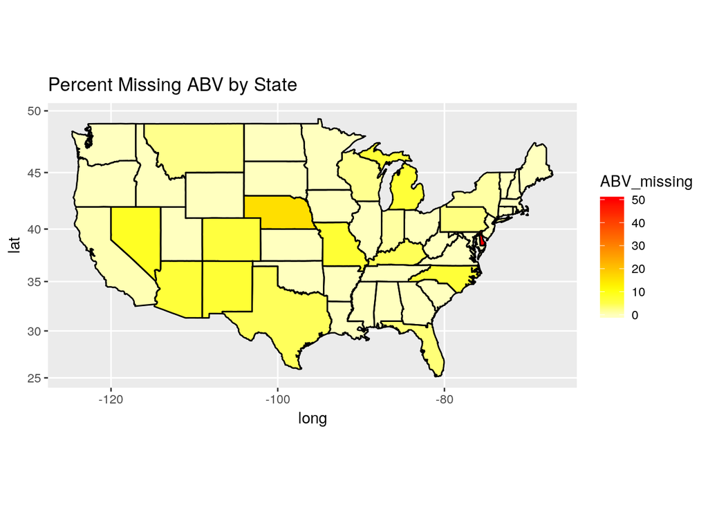

```r
# extract percent missing rows of IBU and ABV by state
missing.by.state <- merged_data %>%
  group_by(region) %>%
  summarise(ABV_missing=prop_miss(ABV) * 100,
            IBU_missing=prop_miss(IBU) * 100)

# build state data and merge beer/brewery data onto map data
states <- map_data("state")
map.df <- merge(states, missing.by.state, by="region", all.x=T)
map.df <- map.df[order(map.df$order),]

# percent missing ABV by state (map plot)
ggplot(map.df, aes(x=long,y=lat,group=group, fill=ABV_missing))+
  geom_polygon()+
  geom_path()+
  scale_fill_gradientn(colours=rev(heat.colors(10)),na.value="grey90")+
  coord_map()+
  labs(title = 'Percent Missing ABV by State')
```

We turn to the question of missingness in IBU, which is a more complicated topic.

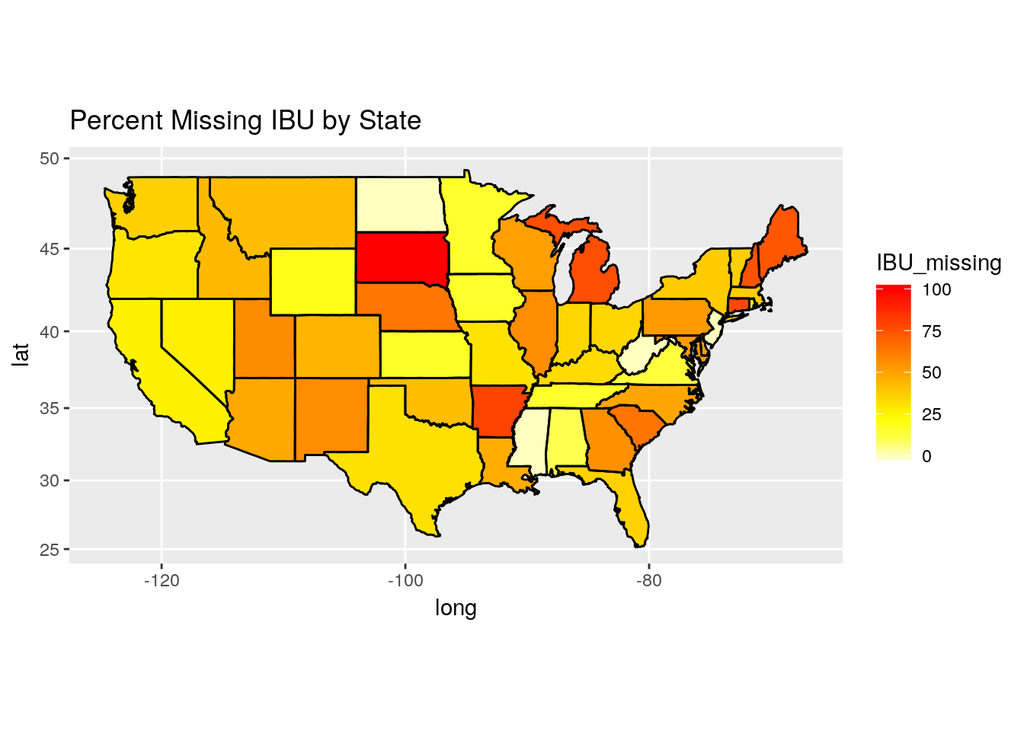

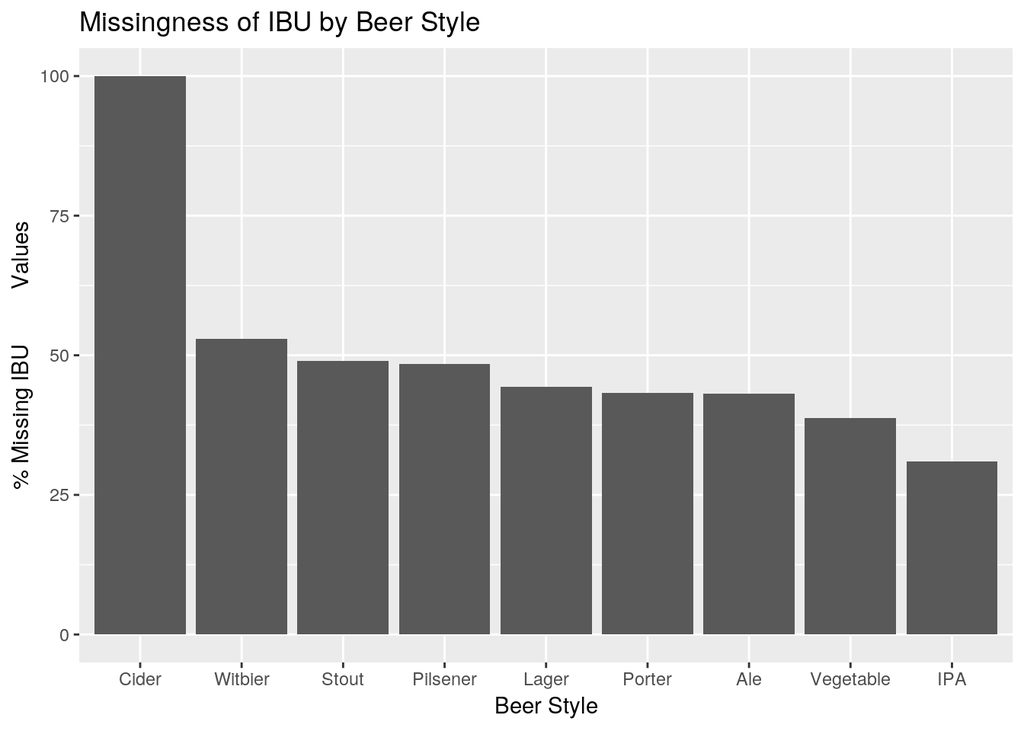

There is clearly a relationship between the beer style, location, and missingness of IBU, so IBU cannot be missing completely at random; therefore, listwise deletion is not acceptable. We will have to look into the question of whether we can build a decent imputation model for IBU at some point in the future. Depending on the nature of the missingness, most parameters for the distribution of IBU may not be recoverable.

Since there is missing data that does not appear to be at random, we suspect the results of this analysis could be biased.

**Comparison of Alcohol Content and Bitterness between States**

```r
# calc summary stats for ABV and IBU
summary_df <- merged_data %>%
  remove_missing(na.rm=TRUE) %>%
  group_by(region) %>%
  summarise(MeanABV=mean(ABV), MaxABV=max(ABV), MinABV=min(ABV), MedianABV=median(ABV), StdABV=sd(ABV),
            MeanIBU=mean(IBU), MaxIBU=max(IBU), MinABV=min(IBU), MedianIBU=median(IBU), StdIBU=sd(IBU))

# build data for mapping
states <- map_data("state")
map.df <- merge(states, summary_df, by="region", all.x=T)
map.df <- map.df[order(map.df$order),]
```

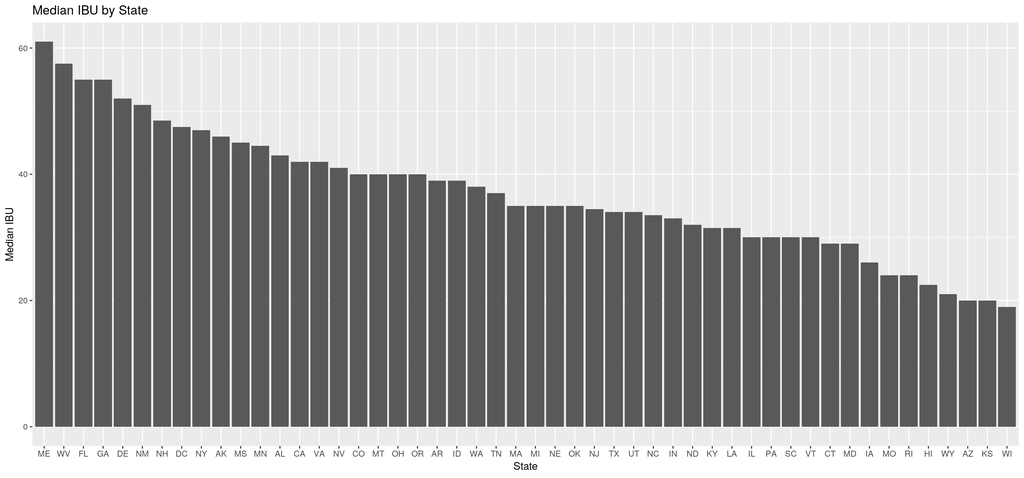

```r
# plot median IBU by state (bar chart)
merged_data %>%
  remove_missing(na.rm=TRUE) %>%
  group_by(State) %>%
  summarise(MedianIBU = median(IBU)) %>%
  ggplot(aes(x=reorder(State, -MedianIBU), y=MedianIBU)) +
  geom_col() +
  labs(title="Median IBU by State", x="State", y="Median IBU")
```

The plot above shows the median IBU values per state. The medians range from 61 to 19 with the highest median from Maine and the lowest median from Wisconsin.

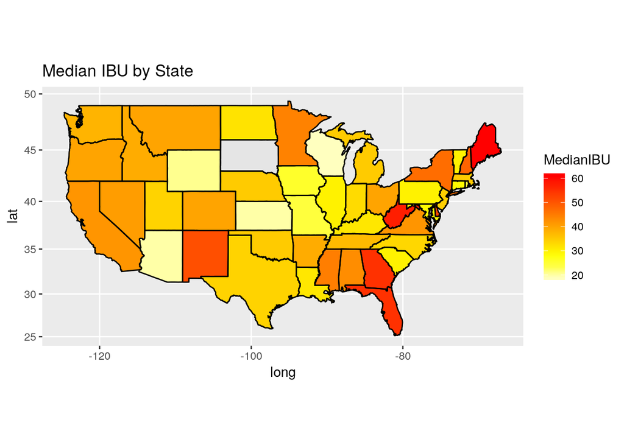

```r
# plot median IBU by state (map plot)
ggplot(map.df, aes(x=long,y=lat,group=group))+
  geom_polygon(aes(fill=MedianIBU))+
  geom_path()+
  scale_fill_gradientn(colours=rev(heat.colors(10)),na.value="grey90")+
  coord_map()+
  labs(title = 'Median IBU by State')
```

The heat map of median IBU by state above shows some regional clustering of median IBU. The median of the upper west states is on the higher side of IBU, the median of the midwest is near the lower end of IBU medians, and the deep south is on the top end of IBU medians.

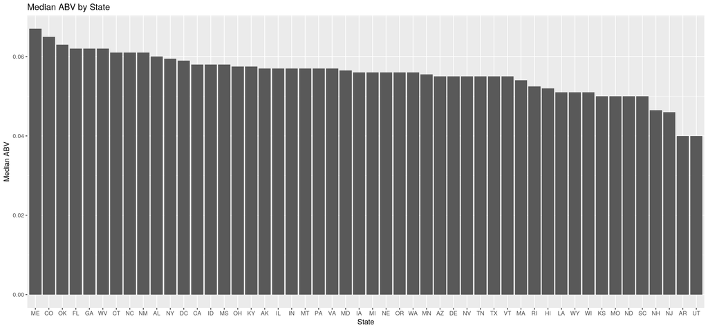

```r
# plot median ABV by state (bar chart)
merged_data %>%
  remove_missing(na.rm=TRUE) %>%
  group_by(State) %>%
  summarize(MedianABV = median(ABV)) %>%
  ggplot(aes(x=reorder(State, -MedianABV), y=MedianABV)) +
  geom_col() +
  labs(title="Median ABV by State", x="State", y="Median ABV")
```

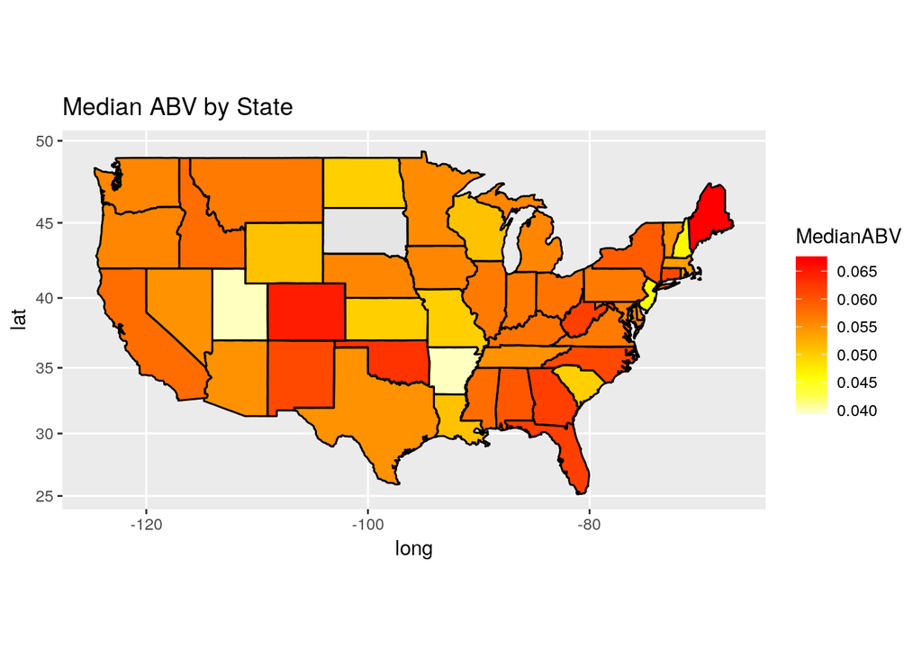

```r
# plot median ABV by state (map plot)
ggplot(map.df, aes(x=long,y=lat,group=group))+
  geom_polygon(aes(fill=MedianABV))+
  geom_path()+
  scale_fill_gradientn(colours=rev(heat.colors(10)),na.value="grey90")+
  coord_map()+
  labs(title = 'Median ABV by State')
```

The heat map of median ABV by state above shows some regional clustering of median ABV. The deep south, some central south states, and some states on the east coast are near the top end of the ABV median scale. The medians of the midwest though the west coast are more moderate on the ABV median scale.

**Which states have the maximum alcoholic (`ABV`) and bitter (`IBU`) beer?**

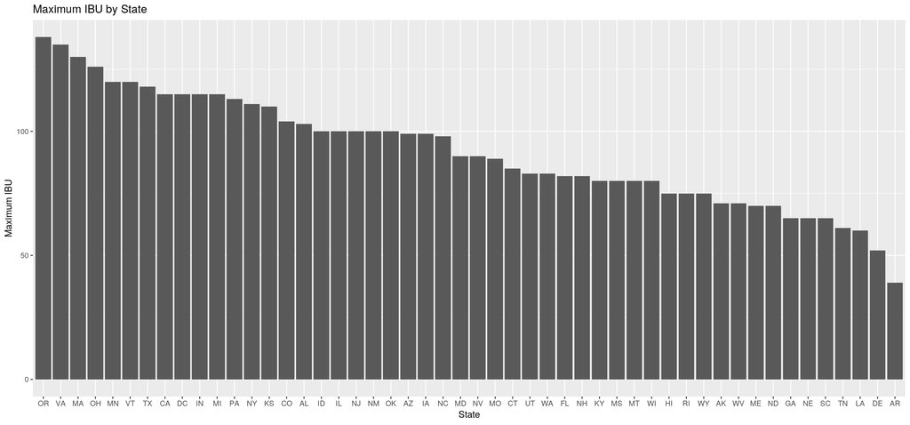

```r
#Max IBUs
merged_data %>%
  remove_missing(na.rm=TRUE) %>%
  group_by(State) %>%
  summarize(MaxIBU = max(IBU)) %>%
  ggplot(aes(x=reorder(State, -MaxIBU), y=MaxIBU)) +
  geom_col() +
  labs(title="Maximum IBU by State", x="State", y="Maximum IBU")
```

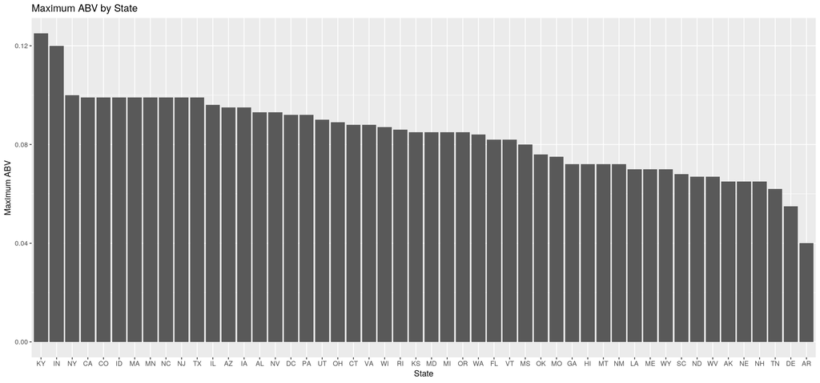

```r
#Max ABVs
merged_data %>%
  remove_missing(na.rm=TRUE) %>%
  group_by(State) %>%
  summarize(MaxABV = max(ABV)) %>%
  ggplot(aes(x=reorder(State, -MaxABV), y=MaxABV)) +
  geom_col() +
  labs(title="Maximum ABV by State", x="State", y="Maximum ABV")
```

**Summary Statistics for the ABV variable.**

```r
# get summary of merged data
merged_data %>%
  summary()
```

```
##     State            Brewery_id        Brewery_name
##  Length:2410        Length:2410        Length:2410
##  Class :character   Class :character   Class :character
##  Mode  :character   Mode  :character   Mode  :character
##
##
##
##
##      City            Beer_name           Beer_ID
##  Length:2410        Length:2410        Length:2410
##  Class :character   Class :character   Class :character
##  Mode  :character   Mode  :character   Mode  :character
##
##
##
##
##       ABV               IBU            Style            Ounces
##  Min.   :0.00100   Min.   :  4.00   Length:2410        12  :1525
##  1st Qu.:0.05000   1st Qu.: 21.00   Class :character   16  : 841
##  Median :0.05600   Median : 35.00   Mode  :character   16.9:   1
##  Mean   :0.05977   Mean   : 42.71                      19.2:  15
##  3rd Qu.:0.06700   3rd Qu.: 64.00                      24  :  22
##  Max.   :0.12800   Max.   :138.00                      32  :   5
##  NA's   :62        NA's   :1005                        8.4 :   1
##    ShortStyle     region
##  Ale    :961   Length:2410
##  IPA    :558   Class :character
##  Lager  :158   Mode  :character
##  Stout  :100
##  Porter : 74
##  (Other):554
##  NA's   :  5
```

The following table summerizes the summary statistics for ABV.

| Statistic | Value |
| --- | --- |
| Min | 0.1% |
| 1st Quartile | 5% |
| Mean | 5.98% |
| Median | 5.60% |
| 3rd Quartile | 6.7% |
| Max | 12.8% |
| standard deviation | 1.35 percentage points |
| range | 12.7 percentage points |

The bulk of the data has an ABV between 5% and 6.7%. The mean and median are fairly different on this scale, likely indicating skew or influence of outliers in the distribution of this variable.

**Is there an apparent relationship between the bitterness of the beer and its alcoholic content?**

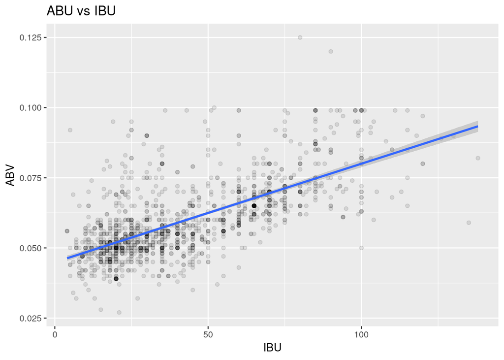

```r
# fits best-fit line to scatter plot
merged_data %>%
  remove_missing(na.rm=TRUE) %>%
  ggplot(aes(x=IBU, y=ABV)) +
  geom_point(alpha=0.1) +
  geom_smooth(method="lm") +
  labs(title="ABU vs IBU")
```

```r
# model output
lm(ABV ~ IBU, data=merged_data) %>%
  summary()
```

```
##
## Call:
## lm(formula = ABV ~ IBU, data = merged_data)
##
## Residuals:
##       Min        1Q    Median        3Q       Max
## -0.033288 -0.005946 -0.001595  0.004022  0.052006
##
## Coefficients:
##              Estimate Std. Error t value Pr(>|t|)
## (Intercept) 4.493e-02  5.177e-04   86.79   <2e-16 ***
## IBU         3.508e-04  1.036e-05   33.86   <2e-16 ***
## ---
## Signif. codes:  0 '***' 0.001 '**' 0.01 '*' 0.05 '.' 0.1 ' ' 1
##
## Residual standard error: 0.01007 on 1403 degrees of freedom
##   (1005 observations deleted due to missingness)
## Multiple R-squared:  0.4497, Adjusted R-squared:  0.4493
## F-statistic:  1147 on 1 and 1403 DF,  p-value: < 2.2e-16
```

```r
# effect size
source("background_code/effect_size.R")
full_model <- lm(ABV ~ IBU, data=merged_data)
reduced_model <- lm(ABV ~ 1, data=merged_data)
get_effect_size(full_model, reduced_model)
```

```
## [1] 0.8173002
```

The plot above is a scatter plot of ABV vs IBU. A simple linear regression yields strong evidence of a linear relationship (p-value < 0.0001). We find that a marginal increase in IBU increases ABV by 0.03%. We compute an effect size of 0.817 using Cohen’s F-squared, which means that the proportion of the variance accounted for above and beyond the sample mean of ABV is very significant.

## Conclusion

### Inferential Scope of Analysis

The details behind the sampling process are unkwown, so it is unclear whether we can generalize our results to a wider population. We also cannot infer causation because there is insufficient theoretical knowledge to make good causal assumptions, especially wit hthe absence of randomization. The missingness of the data poses a problem as well. While the missingness of ABV lends itself to listwise deletion, the missingness of IBU is clearly not completely at random. At best, the missingness of IBU is caused primarily by its location and beer style, but further examination is needed to determine whether an imputation model can recover a consistent estimate of key parameters, like the population mean. If a consistent estimate cannot be recovered, then sampling processes and data governance must be re-examined to obtain better results.